# R package

Dr Wayne Stewart

2020-11-18

# Introduction

Congratulations for getting this far. To complete the evidence that you have made a working R package please answer the following by using the supplied rmd and upload the knitted html to CANVAS.

I will assume your package is called **MYPAC** and you have packaged and documented functions `myf1`, `myf2`, `myf3` and `myf4`.

Your actual package name and functions will obviously be called something else.

# First function

Please place your first function in the r chunk in the following way:

Once you are ready please remove the option `eval = FALSE`

```r
limb.counts = c(15, 8, 63, 20);
limb.labels = c("None", "Both", "Legs ONLY", "Wheels ONLY");
limb.freq.df = as.data.frame(matrix(data= limb.counts/sum(limb.counts), nrow=4, ncol=1), row.names = limb.labels);
limb.freq.df
```

```
##                    V1
## None        0.1415094
## Both        0.0754717
## Legs ONLY   0.5943396
## Wheels ONLY 0.1886792
```

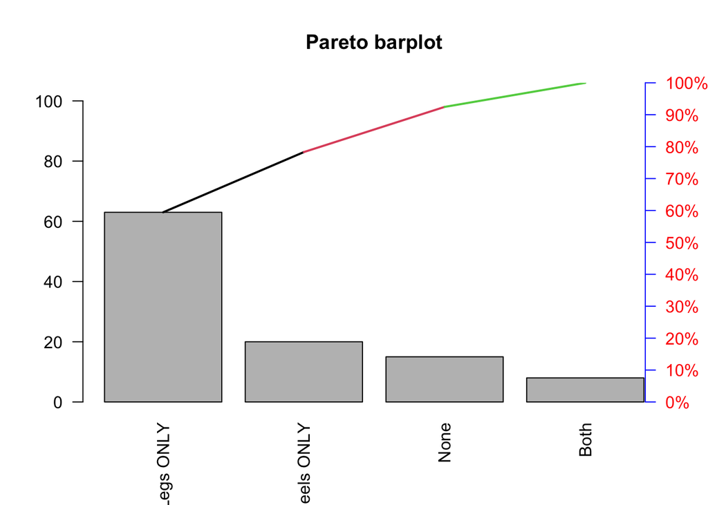

```r
limb.raw = rep(limb.labels, limb.counts);
PackageZuyus::pareto(x=limb.raw)
```

# Second function

Please place your second function in the r chunk in the following way:

Once you are ready please remove the option `eval = FALSE`

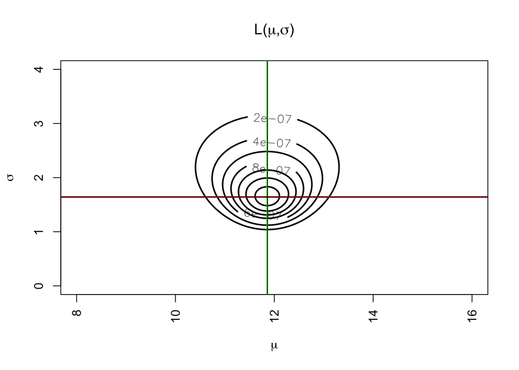

```
## $x
## [1] 10 12 13 15 12 11 10
##
## $coord
##      row col
## [1,] 483 411
##
## $maxl
## [1] 1.513607e-06
##
## $muest
## [1] 11.85986
##
## $sigest
## [1] 1.641642
```

```r
y=c(10,12,13,15,12,11,10)
PackageZuyus::mymlnorm(x=y,mu=seq(8,16,length=1000), sig=seq(0,4,length=1000), lwd=2,labcex=1)
```

# Third function

Please place your third function in the r chunk in the following way:

Once you are ready please remove the option `eval = FALSE`

```r
set.seed(23);x = rnorm(30,mean=10,sd=12)
PackageZuyus::myci(x)
```

```
## [1]  8.124741 15.648939
```

# Forth function

Please place your forth function in the r chunk in the following way:

Once you are ready please remove the option `eval = FALSE`

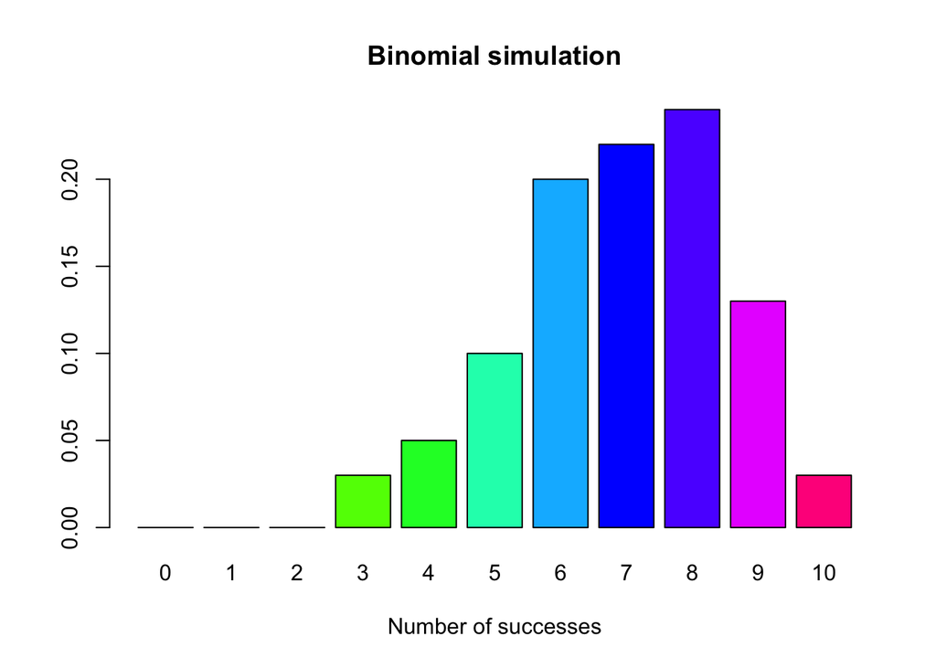

```
##
##    0    1    2    3    4    5    6    7    8    9   10
## 0.00 0.00 0.00 0.03 0.05 0.10 0.20 0.22 0.24 0.13 0.03
```

```r
PackageZuyus::mybin(iter=100, n=10, p=0.7)
```

# The github repository

This is the address of my GITHUB repository: https://github.com/marissazuyus/Stat_PackageZuyus.git

Replace this with your own address.